# OpenIntro Statistics: Chapter 2

Author

Affiliation

Tyler George

Cornell College  
STA 200 Fall 2025 Block 1

## Scatterplot

**Scatterplots** are useful for visualizing the relationship between two numerical variables.

**Do life expectancy and total fertility appear to be *associated* or *independent*?**

They appear to be linearly and negatively associated: as fertility increases, life expectancy decreases.

**Was the relationship the same throughout the years, or did it change?**

The relationship changed over the years.

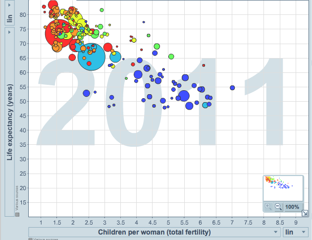

http://www.gapminder.org/world

# Dot Plots and the Mean

## Dot plots

Useful for visualizing one numerical variable. Darker colors represent areas where there are more observations.

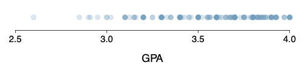

**How would you describe the distribution of GPAs in this data set?**  
Make sure to say something about the center, shape, and spread of the distribution.

## Dot plots & mean

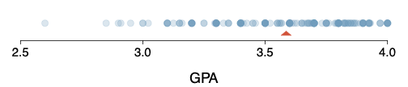

- The **mean**, also called the **average** (marked with a triangle in the above plot), is one way to measure the center of a **distribution** of data.
- The mean GPA is 3.59.

## Mean

- The **sample mean**, denoted as $\bar{x}$, can be calculated as:

  $$\bar{x} = \frac{x_1 + x_2 + \cdots + x_n}{n}$$

  where $x_1, x_2, \cdots, x_n$ represent the **n** observed values.
- The **population mean** is also computed the same way but is denoted as $\mu$. It is often not possible to calculate $\mu$ since population data are rarely available.
- The sample mean is a **sample statistic**, and serves as a **point estimate** of the population mean. This estimate may not be perfect, but if the sample is good (representative of the population), it is usually a pretty good estimate.

## Stacked dot plot

Higher bars represent areas where there are more observations, making it a little easier to judge the center and the shape of the distribution.

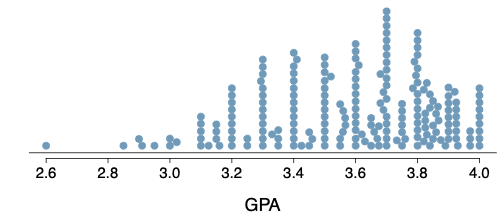

# Histograms and Shape

## Histograms – Extracurricular hours

- Histograms provide a view of the **data density**. Higher bars represent where the data are relatively more common.
- Histograms are especially convenient for describing the **shape** of the data distribution.
- The chosen **bin width** can alter the story the histogram is telling.

## Bin width

**Which one(s) of these histograms are useful? Which reveal too much about the data? Which hide too much?**

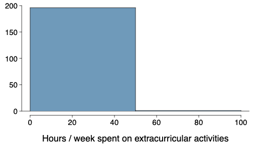

Histogram 1

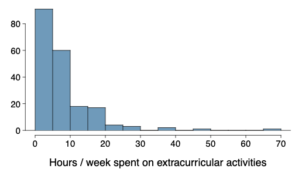

Histogram 3

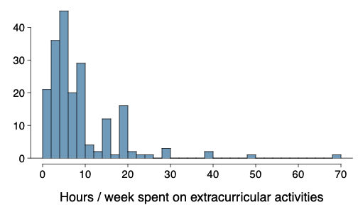

Histogram 4

## Shape of a distribution: modality

Does the histogram have a single prominent peak (**unimodal**), several prominent peaks (**bimodal/multimodal**), or no apparent peaks (**uniform**)?

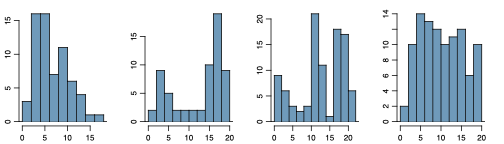

In order to determine modality, step back and imagine a smooth curve over the histogram — imagine that the bars are wooden blocks and you drop a limp spaghetti over them. The shape the spaghetti would take could be viewed as a smooth curve.

## Shape of a distribution: skewness

Is the histogram **right skewed**, **left skewed**, or **symmetric**?

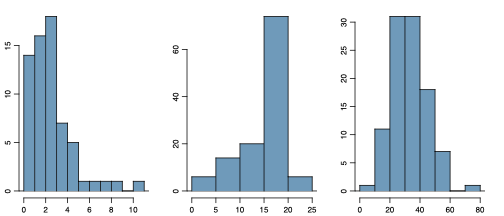

Histograms are said to be skewed to the side of the long tail.

## Shape of a distribution: unusual observations

Are there any unusual observations or potential **outliers**?

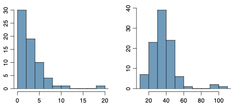

## Extracurricular activities

**How would you describe the shape of the distribution of hours per week students spend on extracurricular activities?**

Unimodal and right skewed, with a potentially unusual observation at 60 hours/week.

## Commonly observed shapes of distributions

unimodal

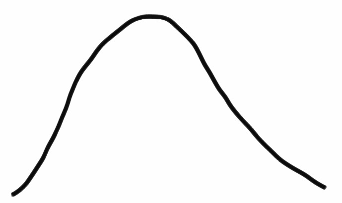

bimodal

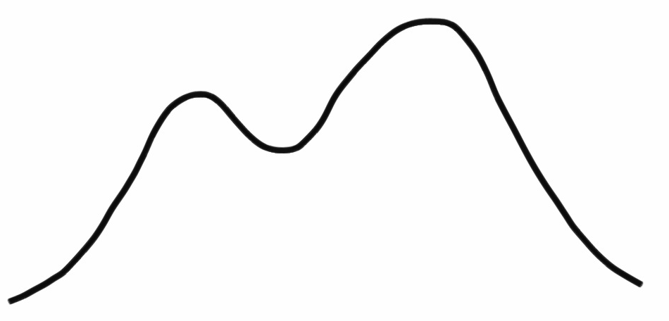

multimodal

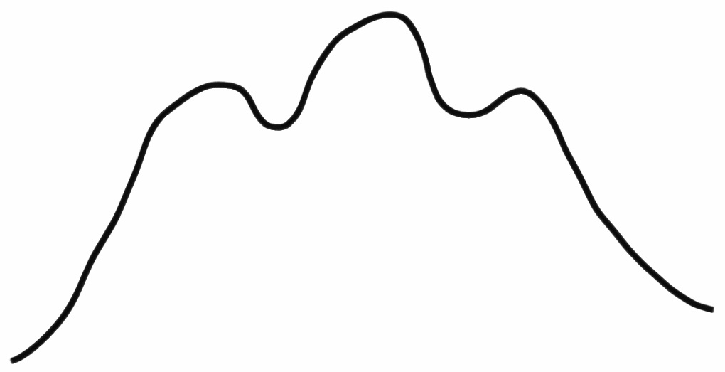

uniform

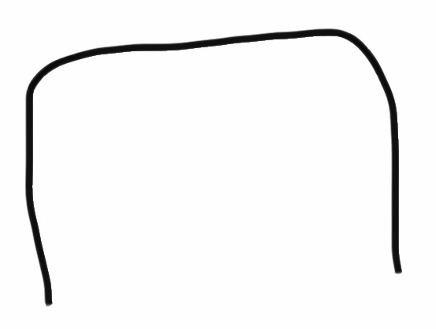

right skew

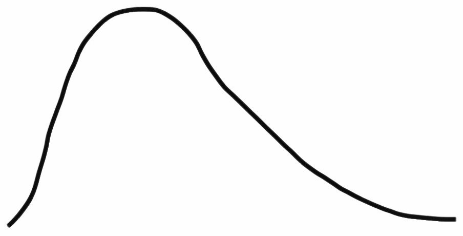

left skew

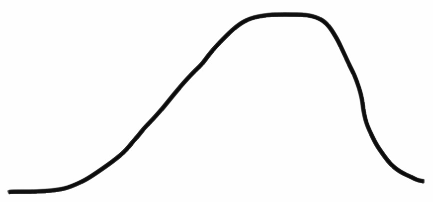

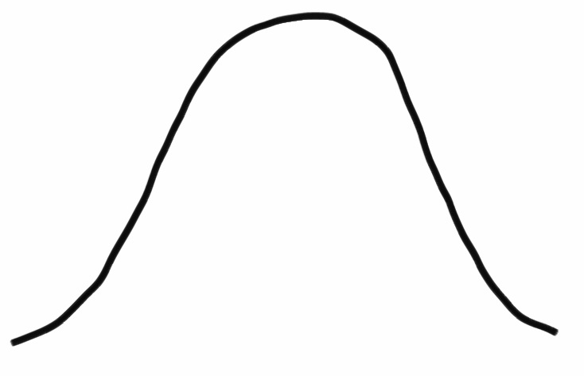

## Practice

**Which of these variables do you expect to be uniformly distributed?**

1. weights of adult females
2. salaries of a random sample of people from North Carolina
3. house prices
4. birthdays of classmates (day of the month)

**Answer:** birthdays of classmates

## Application activity: Shapes of distributions

**Sketch the expected distributions of the following variables:**

- number of piercings
- scores on an exam
- IQ scores

Come up with a concise way (1-2 sentences) to teach someone how to determine the expected distribution of any variable.

## Are you typical?

[figure not shown]

http://www.youtube.com/watch?v=4B2xOvKFFz4

. . .

**How useful are centers alone for conveying the true characteristics of a distribution?**

# Variance and Standard Deviation

## Variance

**Variance** is roughly the average squared deviation from the mean.

$$s^2 = \frac{\sum_{i = 1}^n (x_i - \bar{x})^2}{n - 1}$$

. . .

- The sample mean is $\bar{x} = 6.71$, and the sample size is $n = 217$.  
  . . .
- The variance of amount of sleep students get per night can be calculated as:

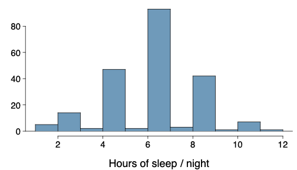

Histogram of sleep hours

. . .

$$s^2 = \frac{(5 - 6.71)^2 + (9 - 6.71)^2 + \cdots + (7 - 6.71)^2}{217 - 1} = 4.11~hours^2$$

## Variance (cont.)

**Why do we use the squared deviation in the calculation of variance?**

. . .

- To get rid of negatives so that observations equally distant from the mean are weighed equally.
- To weigh larger deviations more heavily.

## Standard deviation

The **standard deviation** is the square root of the variance, and has the same units as the data.

$$s = \sqrt{s^2}$$

. . .

- The standard deviation of amount of sleep students get per night can be calculated as:
  $$s = \sqrt{4.11} = 2.03~\text{hours}$$
- We can see that all of the data are within 3 standard deviations of the mean.

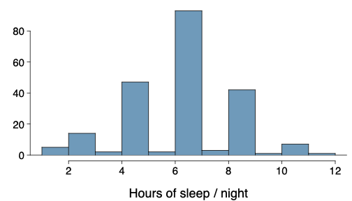

# Box Plots, Quartiles, and the Median

## Median

- The **median** is the value that splits the data in half when ordered in ascending order.

  $$0, 1, \textbf{2}, 3, 4$$
- If there are an even number of observations, then the median is the average of the two values in the middle.

  $$0, 1, \underline{2, 3}, 4, 5 \rightarrow \frac{2 + 3}{2} = \textbf{2.5}$$
- Since the median is the midpoint of the data, 50% of the values are below it. Hence, it is also the $50^{th}$ percentile.

## Q1, Q3, and IQR

- The $25^{th}$ percentile is also called the first quartile, **Q1**.
- The $50^{th}$ percentile is also called the median.
- The $75^{th}$ percentile is also called the third quartile, **Q3**.
- Between Q1 and Q3 is the middle 50% of the data. The range these data span is called the **interquartile range**, or the **IQR**.

$$IQR = Q3 - Q1$$

## Box plot

The box in a **box plot** represents the middle 50% of the data, and the thick line in the box is the median.

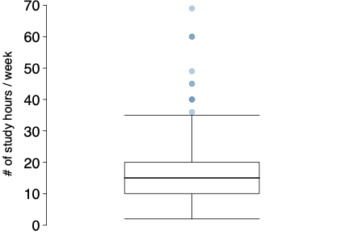

## Anatomy of a box plot

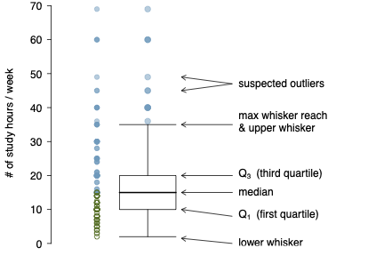

## Whiskers and outliers

- **Whiskers** of a box plot can extend up to $1.5 \times IQR$ away from the quartiles.

$$\begin{aligned}
\text{max upper whisker reach} &= Q3 + 1.5 \times IQR \\
\text{max lower whisker reach} &= Q1 - 1.5 \times IQR
\end{aligned}$$

. . .

$$\begin{aligned}
\text{IQR} &= 20 - 10 = 10 \\
\text{max upper whisker reach} &= 20 + 1.5 \times 10 = 35 \\
\text{max lower whisker reach} &= 10 - 1.5 \times 10 = -5
\end{aligned}$$

. . .

- A potential **outlier** is defined as an observation beyond the maximum reach of the whiskers. It is an observation that appears extreme relative to the rest of the data.

## Outliers (cont.)

**Question:** Why is it important to look for outliers?

. . .

- Identify extreme skew in the distribution.
- Identify data collection and entry errors.
- Provide insight into interesting features of the data.

# Robust Statistics

## Extreme observations

**Question:** How would sample statistics such as mean, median, SD, and IQR of household income be affected if the largest value was replaced with $10 million? What if the smallest value was replaced with $10 million?

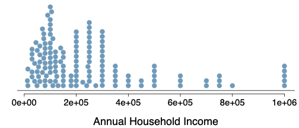

## Robust statistics

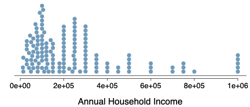

| scenario |  | **robust** |  |  | **not robust** |  |
| --- | --- | --- | --- | --- | --- | --- |
|  |  | median | IQR |  | $\bar{x}$ | $s$ |
| original data |  | 190K | 200K |  | 245K | 226K |
| move largest to $10 million |  | 190K | 200K |  | 309K | 853K |
| move smallest to $10 million |  | 200K | 200K |  | 316K | 854K |

## Robust statistics

Median and IQR are more robust to skewness and outliers than mean and SD. Therefore,

- for skewed distributions it is often more helpful to use median and IQR to describe the center and spread

. . .

- for symmetric distributions it is often more helpful to use the mean and SD to describe the center and spread

. . .

**Question:** If you would like to estimate the typical household income for a student, would you be more interested in the mean or median income?

. . .

**Answer:** Median

## Mean vs. median

- If the distribution is symmetric, center is often defined as the mean: mean ≈ median

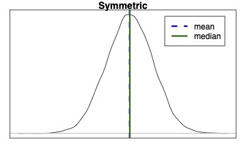

## Mean vs. median (continued)

- If the distribution is skewed or has extreme outliers, center is often defined as the median
  - Right-skewed: mean > median
  - Left-skewed: mean < median

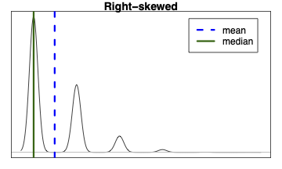

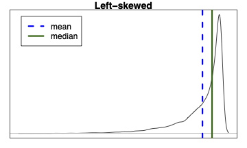

## Practice

**Which is most likely true for the distribution of percentage of time actually spent taking notes in class versus on Facebook, Twitter, etc.?**

. . .

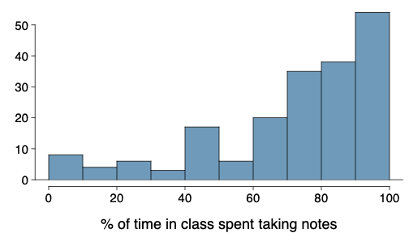

**Median:** 80%  
**Mean:** 76%

1. mean > median
2. mean < median
3. mean ≈ median
4. impossible to tell

**Answer:** mean < median